# ESM 206 Lab 5

## Use ‘lubridate’ to parse dates and times

Since lubridate-type functions show up in various packages, use *lubridate::* to be specific.

Add a new column with *mutate()* that contains my date as an actual date:

```r
class(lobster_tidy$date) # currently date is just stored by R as a character column
```

```
## [1] "character"
```

```r
lobster_date <- lobster_tidy %>%
  mutate(
    date_new = lubridate::mdy(date) # our dates are in M/D/Y
  )

class(lobster_date$date_new)
```

```
## [1] "Date"
```

**Note**: For storing dates in the first place, use ISO format; or better, store year/month/day all in separate columns.

Next, parse the date column to get the different pieces (month, year) separated.

```r
lobster_parse_date <- lobster_date %>%
  mutate(
    obs_yr = lubridate::year(date_new),
    obs_mo = lubridate::month(date_new, label = TRUE), # label equals TRUE if you want it written out rather than the number
    obs_da = lubridate::day(date_new)
  )

levels(lobster_parse_date$obs_mo) # ordering of months is preserved! it's stored as an ordered factor
```

```
##  [1] "Jan" "Feb" "Mar" "Apr" "May" "Jun" "Jul" "Aug" "Sep" "Oct" "Nov"
## [12] "Dec"
```

## Count lobsters by different groupings, using *dplyr::count()*

*?count* to see what it does: groups, tallies, then ungroups

Let’s say I want to count the number of lobsters by year and month:

```r
lobster_yrmo <- lobster_parse_date %>%
  count(obs_yr, obs_mo)

lobster_yrmo
```

```
## # A tibble: 8 x 3
##   obs_yr obs_mo     n
##    <dbl> <ord>  <int>
## 1   2012 Aug      231
## 2   2013 Aug      243
## 3   2014 Aug      404
## 4   2014 Sep      106
## 5   2015 Aug     1100
## 6   2016 Aug      809
## 7   2017 Aug     1668
## 8   2018 Aug     1805
```

Or by observation year, then by site:

```r
lobster_yrsite <- lobster_parse_date %>%
  count(obs_yr, site)

lobster_yrsite
```

```
## # A tibble: 35 x 3
##    obs_yr site      n
##     <dbl> <chr> <int>
##  1   2012 AQUE     38
##  2   2012 CARP     78
##  3   2012 IVEE     26
##  4   2012 MOHK     83
##  5   2012 NAPL      6
##  6   2013 AQUE     32
##  7   2013 CARP     93
##  8   2013 IVEE     40
##  9   2013 MOHK     15
## 10   2013 NAPL     63
## # … with 25 more rows
```

Or just by site:

```r
lobster_site <- lobster_parse_date %>%
  count(site)

lobster_site
```

```
## # A tibble: 5 x 2
##   site      n
##   <chr> <int>
## 1 AQUE    422
## 2 CARP   1619
## 3 IVEE   2304
## 4 MOHK    982
## 5 NAPL   1039
```

group_by + summarize + n() to put it all in one table:

```r
lobster_summary <- lobster_parse_date %>%
  group_by(site) %>%
  summarize(
    mean_size = mean(size_mm, na.rm = TRUE),
    sd_size = sd(size_mm, na.rm = TRUE),
    sample_n = n()
  )
```

## Confidence intervals and t-tests

Use the `t-test()` function to find confidence intervals and perform t-tests

### One-sample t-test

```r
ivee_lobsters <- lobster_tidy %>%
  filter(site == "IVEE") %>% # filter is by rows
  pull(size_mm) # only interested in size_mm column

# Result is just a single vector with each of your size values from IVEE site; but can also call a single column directly

# t-test can calculate confidence interval and perform t-test based on what you give it (1 vector = 1-sample t-test)

t.test(ivee_lobsters) # this is pointless here, but just looking at the confidence interval for the mean
```

```
##
##  One Sample t-test
##
## data:  ivee_lobsters
## t = 245.23, df = 2302, p-value < 2.2e-16
## alternative hypothesis: true mean is not equal to 0
## 95 percent confidence interval:
##  72.99130 74.16806
## sample estimates:
## mean of x
##  73.57968
```

Expect 95% of all other samples to have a mean that falls within the range of ~72.99 to ~74.17.

(This doesn’t make any statement about the true population mean! Often misinterpreted that way.)

### Two-sample t-test

Is there a significant difference between mean lobster lengths between Naples Reef and Mohawk Reef?

```r
napl_sample <- lobster_tidy %>%
  filter(site == "NAPL") %>%
  pull(size_mm)

mohk_sample <- lobster_tidy %>%
  filter(site == "MOHK") %>%
  pull(size_mm)

mohk_napl_ttest <- t.test(napl_sample, mohk_sample)

mohk_napl_ttest
```

```
##
##  Welch Two Sample t-test
##
## data:  napl_sample and mohk_sample
## t = 19.849, df = 1850.8, p-value < 2.2e-16
## alternative hypothesis: true difference in means is not equal to 0
## 95 percent confidence interval:
##  10.19806 12.43436
## sample estimates:
## mean of x mean of y
##  78.18454  66.86833
```

(Note: Welch’s t-test does not assume variances are equal; therefore it’s a slightly more conservative version of the t-test.)

?t.test to see the values associated with the t-test function. Then you can pull any part of the output from running the function:

### Easier way to do a two-sample t-test

```r
lobster_compare <- lobster_tidy %>%
  filter(site %in% c("NAPL", "MOHK"))

ttest2 <- t.test(size_mm ~ site, data = lobster_compare) # compare size_mm variable separated by site (only up to 2!)
ttest2
```

```
##
##  Welch Two Sample t-test
##
## data:  size_mm by site
## t = -19.849, df = 1850.8, p-value < 2.2e-16
## alternative hypothesis: true difference in means is not equal to 0
## 95 percent confidence interval:
##  -12.43436 -10.19806
## sample estimates:
## mean in group MOHK mean in group NAPL
##           66.86833           78.18454
```

## Create a `geom_tile()` heatmap

Heatmaps are good for displaying three different variables in an aesthetically-pleasing way.

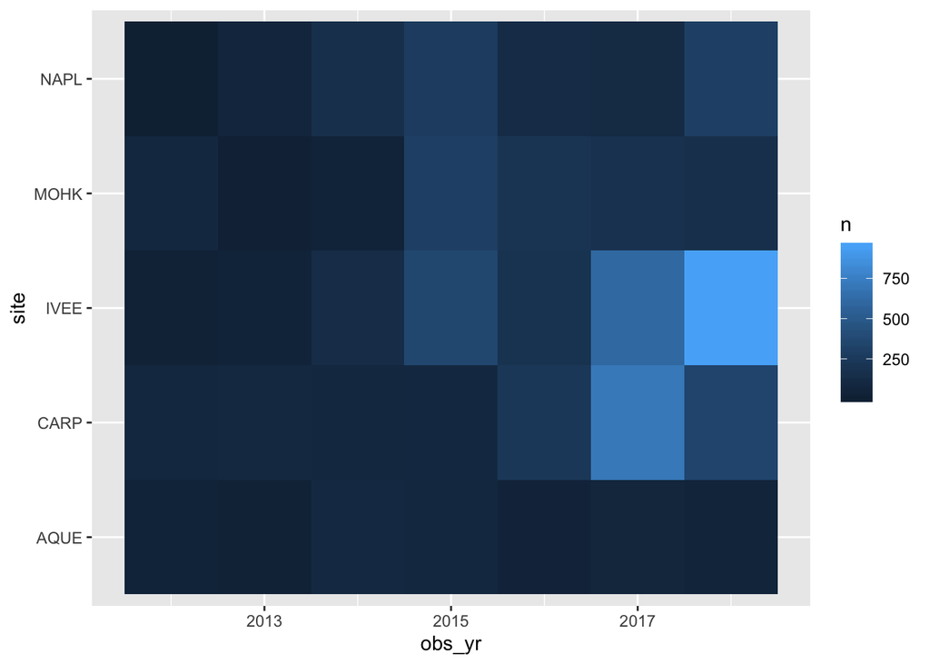

```r
ggplot(data = lobster_yrsite, aes(x = obs_yr, y = site)) +
  geom_tile(aes(fill = n))
```